# Matplotlib Tutorial

This notebook will show you how to draw basic plots using `matplotlib`.

## Import Module

```python
import matplotlib.pyplot as plt
import numpy as np
```

## Line Plot

Plot $y = \cos x$.

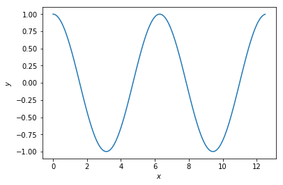

```python
# Data
x = np.arange(0, 4 * np.pi, 0.1) # x in [0, 4 * pi)
y_cos = np.cos(x)

plt.figure()
plt.plot(x, y_cos)
plt.xlabel('$x$')
plt.ylabel('$y$')
plt.show()
```

## Legends, Linestyles, Colors and Markers

Plot $y = 2^x$ an $y = x^2$.

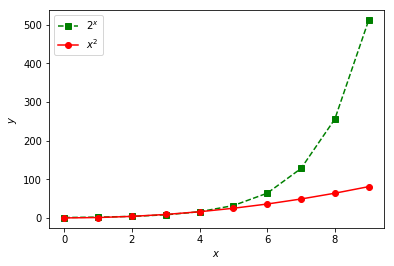

```python
# Data
x = np.arange(0, 10, 1) # x in [0, 10)
y_1 = 2 ** x
y_2 = x ** 2

plt.figure()
# Specifying color, linestyle and marker using keyword arguments
plt.plot(x, y_1, label = '$2^x$', color='g', linestyle='--', marker='s')
plt.plot(x, y_2, label = '$x^2$', color='r', linestyle='-', marker='o')
plt.xlabel('$x$')
plt.ylabel('$y$')
plt.legend(loc = 'upper left')
plt.show()
```

The following cell does the same thing using positional arguments.

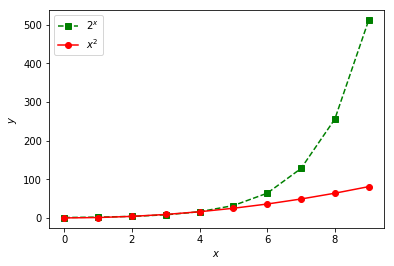

```python
# Data
x = np.arange(0, 10, 1) # x in [0, 10)
y_1 = 2 ** x
y_2 = x ** 2

plt.figure()
# Specifying color, linestyle and marker using positional arguments
plt.plot(x, y_1, 'g--s', label = '$2^x$')
plt.plot(x, y_2, 'r-o', label = '$x^2$')
plt.xlabel('$x$')
plt.ylabel('$y$')
plt.legend(loc = 'upper left')
plt.show()
```

## Title and Font Size

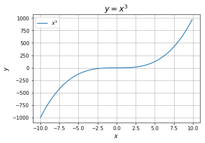

```python
plt.rc('font', size=10)          # controls default text sizes
plt.rc('axes', titlesize=10)     # fontsize of the axes title
plt.rc('axes', labelsize=12)     # fontsize of the x and y labels
plt.rc('xtick', labelsize=10)    # fontsize of the tick labels
plt.rc('ytick', labelsize=10)    # fontsize of the tick labels
plt.rc('legend', fontsize=10)    # legend fontsize

x = np.arange(-10, 10, 0.1)
y = x ** 3

plt.figure()
plt.plot(x, y, label = '$x^3$')
plt.xlabel('$x$', fontsize = 12) # The fontsize can be set here as well
plt.ylabel('$y$', fontsize = 12)
plt.title('$y = x^3$', fontsize = 16) # Set title and its fontsize
plt.legend(loc = 'upper left')
plt.grid()
plt.show()
```

## Suplots

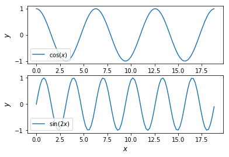

```python
# Data
x = np.arange(0, 6 * np.pi, 0.2)
y_1 = np.cos(x)
y_2 = np.sin(2 * x)

# Plot y = cos(x)
plt.figure()
plt.subplot(2, 1, 1)
plt.plot(x, y_1, label = '$\cos(x)$')
plt.xlabel('$x$')
plt.ylabel('$y$')
plt.legend(loc = 'lower left')

# Plot y = sin(2x)
plt.subplot(2, 1, 2)
plt.plot(x, y_2, label = '$\sin(2x)$')
plt.xlabel('$x$')
plt.ylabel('$y$')
plt.legend(loc = 'lower left')
plt.show()
```

## Shared Axes

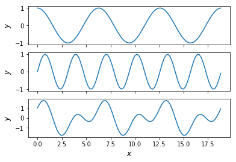

```python
# Data
x = np.arange(0, 6 * np.pi, 0.2)
y_1 = np.cos(x)
y_2 = np.sin(2 * x)
y_3 = y_1 + y_2

fig, axs = plt.subplots(3, 1, sharex = True)
axs[0].plot(x, y_1)
axs[1].plot(x, y_2)
axs[2].plot(x, y_3)
axs[0].set_ylabel('$y$')
axs[1].set_ylabel('$y$')
axs[2].set_ylabel('$y$')
axs[2].set_xlabel('$x$')
plt.show()
```

## Bar Plot

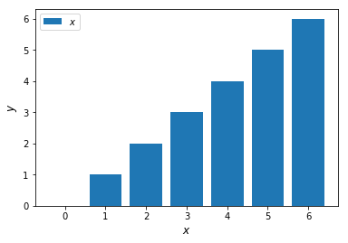

```python
# Data
x = np.arange(0, 7, 1) # x in [2, 7)
y = x

plt.figure()
plt.bar(x, y, label = '$x$')
plt.xlabel('$x$')
plt.ylabel('$y$')
plt.legend(loc = 'upper left')
plt.show()
```

## Multiple Axis

Sometimes it is useful to have multiple y-axis in the same plot.

For example, if we want to investigate the corrleation between the obesity rate of a country and the amount of calories that people in this country have per meal.

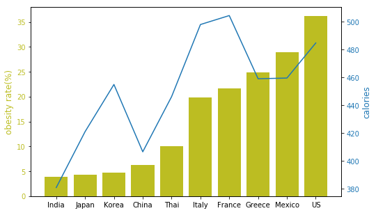

```python
# Make-up data
calories = [380.70, 420.98, 454.91, 406.45, 446.16, 498.08, 504.54, 459.05, 459.55, 484.79]
countries = ['India', 'Japan', 'Korea', 'China', 'Thai', 'Italy', 'France', 'Greece', 'Mexico', 'US']
obesity_rates = [3.9, 4.3, 4.7, 6.2, 10, 19.9, 21.6, 24.9, 28.9, 36.2]

fig, ax1 = plt.subplots(figsize = (8, 5))
ax1.bar(countries, obesity_rates, color='C8')
ax1.set_ylabel('obesity rate(%)', color='C8')
ax1.tick_params(axis='y', labelcolor='C8')

ax2 = ax1.twinx()
ax2.plot(countries, calories, color='C0')
ax2.set_ylabel('calories', color='C0')
ax2.tick_params(axis='y', labelcolor='C0')
plt.show()
```

## Scatter Plot

A scatter plot displays values for typically two variables for a set of data. The data are displayed as a collection of points

Plot $y = 2x + 3 + \epsilon$, where $\epsilon \sim \mathcal{N}(0, 1)$. The following code makes a scatter plot for all $(x, y)$ pairs.

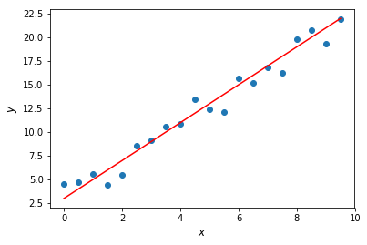

```python
# Data
x = np.arange(0, 10, 0.5) # x in [0, 10)
noise = np.random.randn(len(x)) # Generate standard normal random variables
y = 2 * x + 3 + noise

plt.figure()
plt.scatter(x, y)
plt.plot(x, 2 * x + 3, color = 'r')
plt.xlabel('$x$')
plt.ylabel('$y$')
plt.show()
```

## Contour Plot

A contour plot represents a 3-dimensional surface by plotting constant $z$ slices (contours). Given a value for $z$, lines are drawn for connecting the $(x,y)$ coordinates where that $z$ value occurs.

Plot the contours of $J(\mathbf{w})$

$$ J(\mathbf{w}) = (\mathbf{w} - \mathbf{w}_{o})^{T}\mathbf{A}(\mathbf{w} - \mathbf{w}_{o}) $$

where $\mathbf{w} = \begin{bmatrix} -2 \\ 2 \end{bmatrix}$, $\mathbf{A} = \begin{bmatrix} 2 & 0 \\ 0 & 1 \end{bmatrix}$.

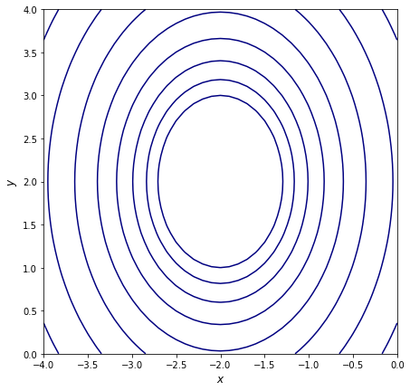

```python
xmin, xmax, xstep = -4, 0, .1
ymin, ymax, ystep = 0, 4, .1

A = np.array([[2, 0], [0, 1]])
w0 = np.array([-2., 2.]).reshape(2, 1)

J = lambda x, y: A[0, 0] * (x - w0[0]) ** 2 + (A[0, 1] + A[1, 0]) * (x - w0[0]) * (y - w0[1]) + A[1, 1] * (y - w0[1]) ** 2
gradient_u = lambda x, y: (A[0, 0] * (x - w0[0]) + A[0, 1] * (y - w0[1])) + (A[0, 0] * (x - w0[0]) + A[1, 0] * (y - w0[1]))
gradient_v = lambda x, y: (A[1, 0] * (x - w0[0]) + A[1, 1] * (y - w0[1])) + (A[0, 1] * (x - w0[0]) + A[1, 1] * (y - w0[1]))

x, y = np.meshgrid(np.arange(xmin, xmax + xstep, xstep),
                   np.arange(ymin, ymax + ystep, ystep))

z = J(x, y)

fig, ax = plt.subplots(figsize=(7,7))
ax.contour(x, y, z, levels=np.logspace(0, 5, 35), cmap='jet')
ax.set_xlabel('$x$')
ax.set_ylabel('$y$')
ax.set_xlim((xmin, xmax))
ax.set_ylim((ymin, ymax))
plt.show()
```

## Quiver Plot

A quiver plot displays velocity vectors as arrows with components $(u,v)$ at the points $(x,y)$.

Plot $\nabla J(\mathbf{w}) = 2\mathbf{A}\mathbf{w} - 2\mathbf{A}\mathbf{w}_{o}$.

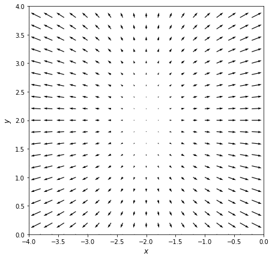

```python
x1, y1 = np.meshgrid(np.arange(xmin, xmax, 0.2),
                   np.arange(ymin, ymax, 0.2))
u1 = gradient_u(x1, y1)
v1 = gradient_v(x1, y1)

fig, ax = plt.subplots(figsize=(7, 7))
ax.quiver(x1, y1, u1, v1)
ax.set_xlabel('$x$')
ax.set_ylabel('$y$')
ax.set_xlim((xmin, xmax))
ax.set_ylim((ymin, ymax))
plt.show()
```

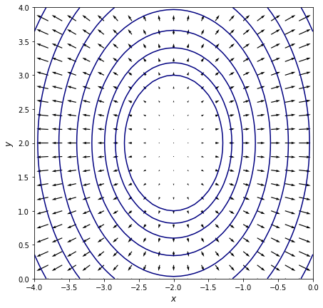

```python
fig, ax = plt.subplots(figsize=(7, 7))
ax.contour(x, y, z, levels=np.logspace(0, 5, 35), cmap='jet')
ax.quiver(x1, y1, u1, v1)
ax.set_xlabel('$x$')
ax.set_ylabel('$y$')
ax.set_xlim((xmin, xmax))
ax.set_ylim((ymin, ymax))
plt.show()
```

## 3D Faces

Besides of contour plot, we can directly plot the 3D faces as well using `matplotlib`.

Plot the 3D-face of 2D [joint Gaussian distribution](https://en.wikipedia.org/wiki/Multivariate_normal_distribution).

$\boldsymbol{\mu} = \begin{bmatrix} 0 \\ 0 \end{bmatrix} $, $\boldsymbol{\Sigma} = \begin{bmatrix} 1 & 0 \\ 0 & 1 \end{bmatrix} $.

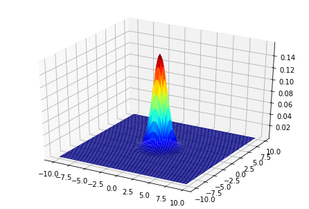

```python
import numpy as np
from mpl_toolkits.mplot3d import Axes3D
from matplotlib import cm
import matplotlib.pyplot as plt
from scipy.stats import multivariate_normal

Mu = np.array([0, 0])
Cov = np.array([[1, 0], [0, 1]])
rv = multivariate_normal(Mu, Cov)

fig = plt.figure()
ax = Axes3D(fig)
X = np.arange(-10, 10, 0.25)
Y = np.arange(-10, 10, 0.25)
X, Y = np.meshgrid(X, Y)
pos = np.empty(X.shape + (2,))
pos[:, :, 0] = X; pos[:, :, 1] = Y
Z = rv.pdf(pos)
ax.plot_surface(X, Y, Z, rstride=1, cstride=1, cmap=cm.jet)
plt.show()
```

$\boldsymbol{\mu} = \begin{bmatrix} 0 \\ 4 \end{bmatrix} $, $\boldsymbol{\Sigma} = \begin{bmatrix} 5 & 0 \\ 0 & 1 \end{bmatrix} $.

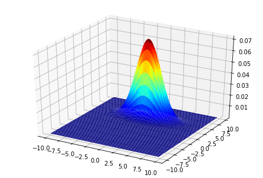

```python
Mu = np.array([0, 4])
Cov = np.array([[5, 0], [0, 1]])
rv = multivariate_normal(Mu, Cov)

fig = plt.figure()
ax = Axes3D(fig)
X = np.arange(-10, 10, 0.25)
Y = np.arange(-10, 10, 0.25)
X, Y = np.meshgrid(X, Y)
pos = np.empty(X.shape + (2,))
pos[:, :, 0] = X; pos[:, :, 1] = Y
Z = rv.pdf(pos)
ax.plot_surface(X, Y, Z, rstride=1, cstride=1, cmap=cm.jet)
plt.show()
```

$\boldsymbol{\mu} = \begin{bmatrix} 0 \\ 0 \end{bmatrix} $, $\boldsymbol{\Sigma} = \begin{bmatrix} 10.5 & -9.5 \\ -9.5 & 10.5 \end{bmatrix} $.

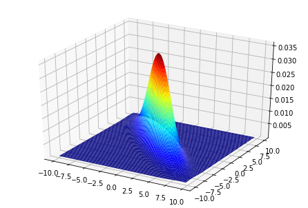

```python
Mu = np.array([0, 0])
Cov = np.array([[10.5, -9.5], [-9.5, 10.5]])
rv = multivariate_normal(Mu, Cov)

fig = plt.figure()
ax = Axes3D(fig)
X = np.arange(-10, 10, 0.25)
Y = np.arange(-10, 10, 0.25)
X, Y = np.meshgrid(X, Y)
pos = np.empty(X.shape + (2,))
pos[:, :, 0] = X; pos[:, :, 1] = Y
Z = rv.pdf(pos)
ax.plot_surface(X, Y, Z, rstride=1, cstride=1, cmap=cm.jet)
plt.show()
```

## Box Plot

In this example we use the dataset [California Housing Prices](https://www.kaggle.com/camnugent/california-housing-prices), which contains information from the 1990 California census. `seaborn`, a high-level API based on `matplotlib`, is also used.

A box plot shows the interquartile range, midhinge, range, mid-range, and trimean of the data. Dots the whiskers are outliers.

```python
import pandas as pd
import numpy as np
import matplotlib.pyplot as plt
import seaborn as sns

df = pd.read_csv('./housing.csv')
df = df.dropna()

plt.figure(figsize = (10, 6))
sns.boxplot(data=df, x = 'ocean_proximity', y = 'median_house_value', palette = 'viridis')
plt.show()
```

[output not shown]

[output not shown]

## Correlation Matrix Heatmap

```python
import pandas as pd
import numpy as np
import matplotlib.pyplot as plt
import seaborn as sns

df = pd.read_csv('./housing.csv')
df = df.dropna()

plt.figure(figsize=(10, 6))
sns.heatmap(cbar=False,annot=True,data=df.corr(),cmap='coolwarm')
plt.title('Correlation Matrix')
plt.show()
```

[output not shown]

[output not shown]

## IPython Widgets

Plot $ y = \cos(\omega_1 x) + \cos(\omega_2 x)$. $\omega_1$ and $\omega_2$ are controlled by sliders.

```python
import numpy as np
import matplotlib.pyplot as plt
import ipywidgets as widgets

@widgets.interact(s1=(1, 30.0), s2=(1, 30.0), continuous_update=False)
def f(s1, s2):
    plt.figure()
    x = np.arange(0, 20 * np.pi, 0.1)
    y = np.cos(s1 * x) + np.cos(s2 * x)
    plt.plot(x, y)
    plt.show()
```

## Matplotlib Widgets

If you want to use sliders outside notebooks, `matplotlib` provides an option for you. Copy the follow block of code to a `.py` file and run it.

The following example plots $ y = \cos(\omega_1 x) + \cos(\omega_2 x)$. $\omega_1$ and $\omega_2$ are controlled by sliders.

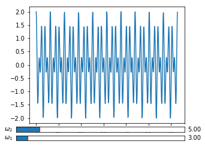

```python
import numpy as np
import matplotlib.pyplot as plt
from matplotlib.widgets import Slider

x = np.arange(0, 20 * np.pi, 0.1)
y = np.cos(3 * x) + np.cos(5 * x)

fig, ax = plt.subplots()
plt.subplots_adjust(bottom=0.2,left=0.3)
l, = plt.plot(x, y)

om1= plt.axes([0.25, 0.1, 0.65, 0.03])
om2 = plt.axes([0.25, 0.15, 0.65, 0.03])

som1 = Slider(om1, r'$\omega_1$', 1, 30.0, valinit=3)
som2 = Slider(om2, r'$\omega_2$', 1, 30.0, valinit=5)

def update(val):
    s1 = som1.val
    s2 = som2.val
    x = np.arange(0, 20 * np.pi, 0.1)
    y = np.cos(s1 * x) + np.cos(s2 * x)
    l.set_ydata(y)
    l.set_xdata(x)

som1.on_changed(update)
som2.on_changed(update)

plt.show()
```